# Pricing counterparty risk

A bank's derivative contracts are worth less if the institution on the other side might fail before paying. This project puts a number on that risk, then tests what actually reduces it.

Monte Carlo simulation CDS bootstrapping R Excel

Portfolio charge

10,485*PLN*

Saved by netting

18.2*%*

With collateral

1,942*PLN*

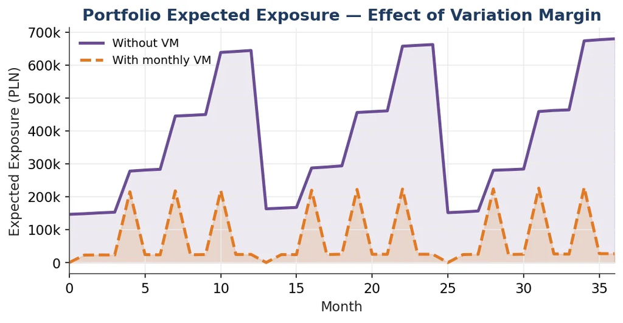

Exposure to the counterparty before and after monthly collateral. Margin removes 81.5 percent of the credit charge.

01

## Problem

Two banks sign a derivative contract. Each depends on the other staying solvent until it settles. If one fails first, the other loses whatever it was owed. The **credit valuation adjustment** is the price of that risk, and banking regulation requires it to be held as capital.

- A derivative has no fixed balance owed. Its value moves every day with the market.
- It can be worth money to either side, so the amount at risk keeps changing.
- Exposure at the moment of default therefore has to be simulated, not looked up.

Problem statement

Calculate the credit valuation adjustment on a portfolio of two derivative contracts held against one bank counterparty, and measure how far netting and collateral reduce it.

### What was given

| Contract | Notional | Terms | Maturity |
| --- | --- | --- | --- |
| **EUR/PLN forward** | EUR 1,000,000 | Buy euro, sell złoty at 4.4439 | 3 years |
| **Interest rate swap** | EUR 10,000,000 | Receive 2.02 percent fixed, pay EURIBOR 3M | 3 years |

Market history

766 daily observations of EUR/PLN and EURIBOR 3M, 2023 to 2025

Credit curve

Counterparty CDS quotes at 30.5, 39.4, 69.4 and 96.7 basis points

Interest rates

Euro 2.00 percent, złoty 3.75 percent

Recovery

40 percent, so 60 percent of exposure is lost on default

02

## Solution

The charge is a sum across every month in the life of the portfolio. Three quantities are multiplied together in each month, and the total is scaled by the share of exposure that would actually be lost.

CVA = LGD × Σ [ exposure × default probability × discount factor ]

- **Exposure.** How much would be owed at that date.
- **Default probability.** The chance the counterparty fails during that month.
- **Discount factor.** What a future loss is worth today.
- **Loss given default.** 60 percent, the share not recovered in a failure.

Stage one

### Simulate the market

- Ten thousand possible futures for the exchange rate and the interest rate.
- Each stepped forward one month at a time across three years.
- The exchange rate follows geometric Brownian motion, which keeps it positive.
- The interest rate follows arithmetic Brownian motion, which allows negative rates.

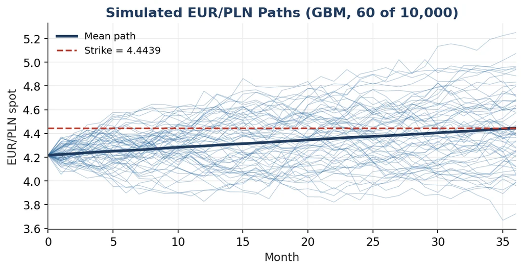

Exchange rate paths widen as the horizon lengthens.

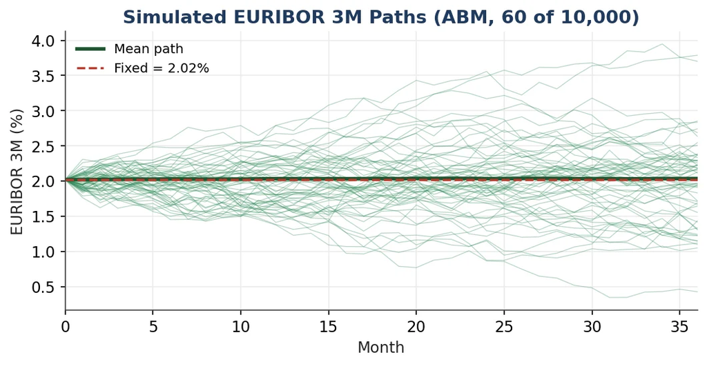

Stage two

### Measure the exposure

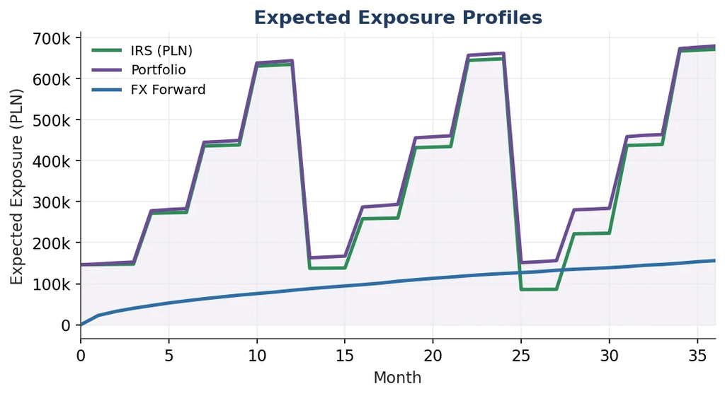

The portfolio line sits on top of the swap line. The sawtooth appears because the swap resets at each annual coupon.

Stage three

### Price the default risk

- Default probability was read from market prices rather than assumed.
- Credit default swaps pay out if a company fails, so their quotes imply how likely that is.
- Working through the quoted maturities one at a time recovers a survival curve.
- That curve becomes a probability of default in each individual month.

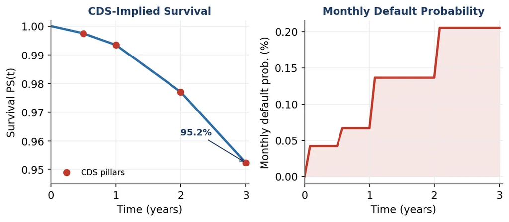

The market prices a 4.8 percent chance of default within three years, with risk rising toward the end of the horizon.

Judgement call

### Correlation was measured before it was modelled

The brief asked for the two risk factors to be simulated together, linked by their historical correlation. That correlation was measured first and came out at **0.014**, close to zero.

Factors that barely move together gain nothing from being linked, so they were simulated separately and the reasoning recorded. Same answer, simpler model.

03

## Result

| Level | Charge (PLN) | Effect |
| --- | --- | --- |
| Forward alone | 3,126 |  |
| Swap alone | 9,699 |  |
| Priced separately | 12,825 | No netting |
| Netted portfolio | 10,485 | 18.2 percent lower |
| With monthly margin | 1,942 | 81.5 percent lower again |

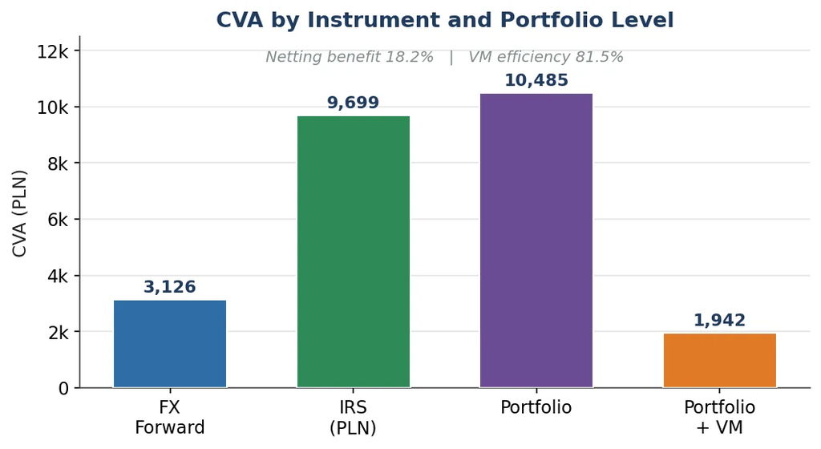

The charge at each level of mitigation.

**The swap drives the charge**

It carries ten times the notional of the forward, and its exposure grows toward maturity instead of fading away.

**Netting saved less than expected**

The two risk factors barely move together and one contract is far larger, so there is little for the offsets to work against.

**Collateral was the effective tool**

Exchanging margin every month removed more than four fifths of the charge, leaving only the movement between calls.

Full R code and Excel workbook available on request

Request the files [LinkedIn](https://www.linkedin.com/in/gautamprasadwork/)